# Analisis Encuesta

Jean Paul

9/7/2020

# Introducción

En el año 2020, semestre 2, se dejó una actividad de ver el primer episodio de la aclamada serie numb3rs, el presente informe es una ánalisis descriptivo y exploratorio de una encuesta realizada sobre aquella actividad.

# Análisis descriptivo de las personas que vieron el primer episodio

## Análisis

Con base en los datos, se puede ver que un 60% realizaron la tarea y vieron el primer episodio de la temporada numb3rs, despues se profundizará en las razones por las cuales algunos no hicieron la tarea, pero el balance de la primera tarea es postivo debido a que la mayoría hizo la tarea.

## Tabla de frecuencias de personas que vieron el primer episodio de la temporada Numb3rs

```
##
## No Si
## 49 74
```

## Porcentaje de personas que vieron el primer episodio de la temporada Numb3rs

```
##
##    No    Si
## 39.84 60.16
```

## Gráfica personas que vieron el primer episodio de la temporada Numb3rs

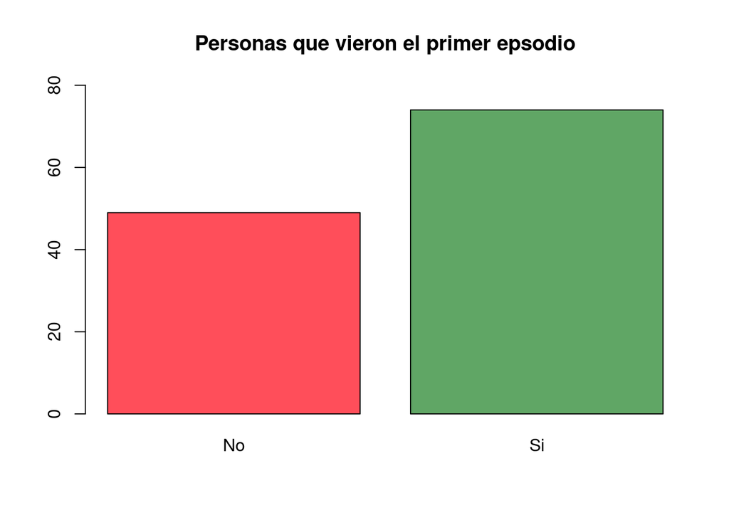

# Análisis descriptivo del ejemplo de Charlie

## Análisis

Prácticamente todos respondieron que el ejemplo que uso Charlie para convencer a su hermano fue la regadera, solo hubo tres personas que tuvieron una respuesta completamente diferente que no tiene nada que ver con la regadera.

## Tabla de frecuencias del ejemplo charlie

```
##
##            Agujeros negros Agujeros negros y regadera
##                          2                          1
##               Probabilidad                   Regadera
##                          1                         68
```

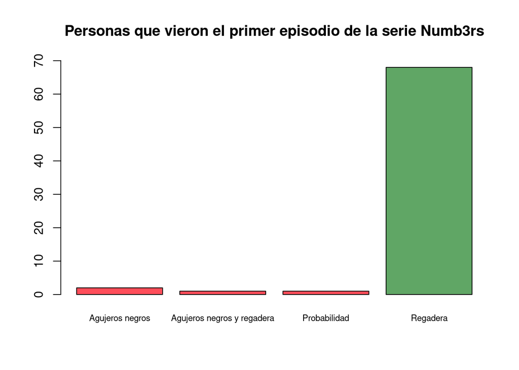

# Análisis excusas

## Análisis

Las personas que no vieron el episodio fue debido a que tuvieron problemas de conectividad y que ignoraban a que debían ver el video, las razones por las que ignoraban puede ser debido a que no leyeron el correo en donde se daba la indicación de ver el capitulo. El resto de los que no hicieron la tarea se dee a razones personales.

En la reclasificación que realizé propuse reducir las categorías y eliminar las personas que no contestaron la pregunta, eliminé las personas que no la contestaron porque no ayudan al analisis de esta variable y poder enfocarme en las razones que los estudiantes pusieron. Combinando algunas filas llegue a una tabla en donde solo estan los motivos laborales, academicos, personales y otras tres excusas representativas: problemas técnicos, ignoraban que había que ver el video y no revisar el correo. Los problemas técnicos es una nueva excusa que junta los problemas con el computador o el internet.

Con esta reclasificación podemos ver que los dos factores mas importantes por las cuales las personas no vieron el capitulo fue por los problemas con su computador y que no se enteraron de la actividad.

## Tabla excusas

```
## excusas
##            Falta de organización de tiempo
##                                          1
##                        No revise el correo
##                                          1
##                         Problemas de salud
##                                          1
##                                        N/N
##                                          2
##        Inscripcion del curso en otra fecha
##                                          3
## Cuestiones tecnicas del uso del computador
##                                          4
##                  Por cuestiones academicas
##                                          4
##                  Por cuestiones de trabajo
##                                          5
##                           No revise correo
##                                          6
##                  Por cuestiones personales
##                                          6
##       Ignoraba que había que ver el video.
##                                         13
##           Problemas de conexión a internet
##                                         17
```

## Grafica excusas

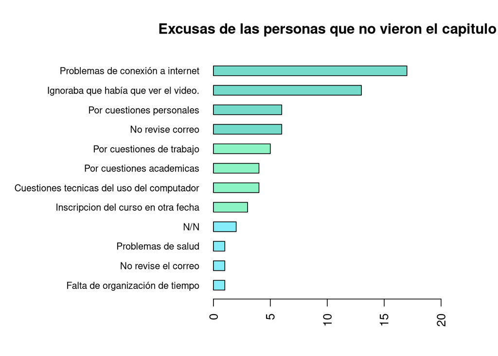

## Reclasficación excusas

```
##                                 excusas Freq
## 8             Por cuestiones de trabajo    5
## 2                   No revise el correo    7
## 7             Por cuestiones academicas    7
## 10            Por cuestiones personales    8
## 11 Ignoraba que había que ver el video.   13
## 12                   Problemas técnicos   21
```

## Gráfica excusas reclasificadas

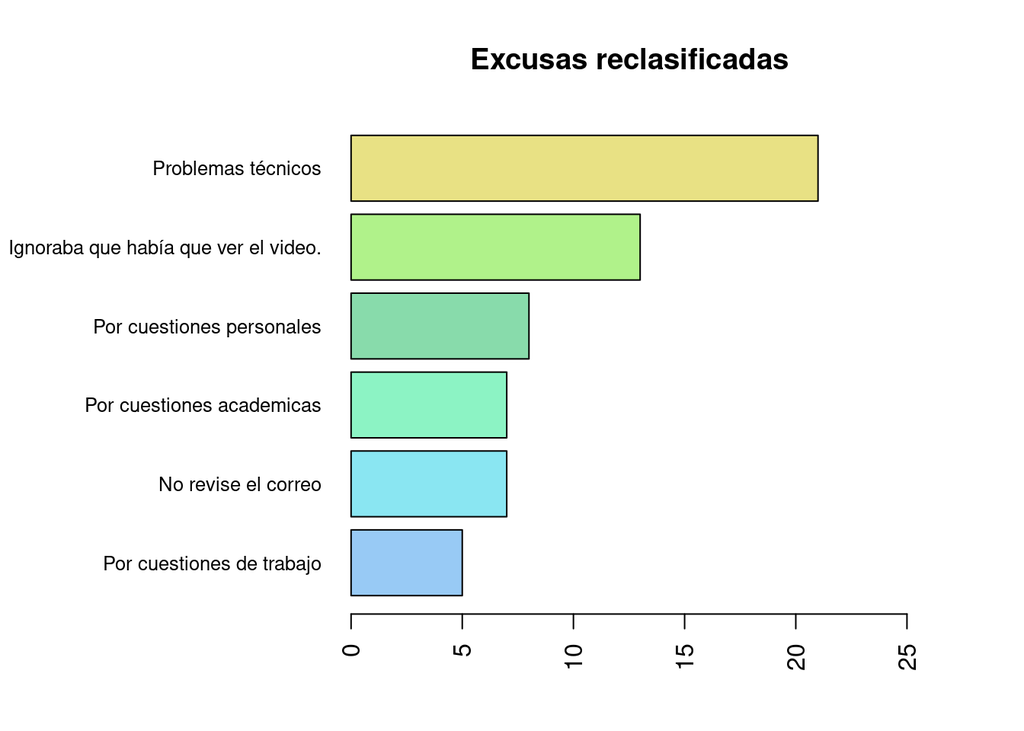

# Análisis sobre las acciones para atrapar al asesino

## Tabla pregunta Charlie depurada

```
##
## A traves de las matematicas generar una ecuacion para lograr su ubicación
##                                                                        41
##              Encontrar una zona de vivienda o de concurrencia del asesino
##                                                                        31
```

## Gráfica de la pregunta Charlie depurada

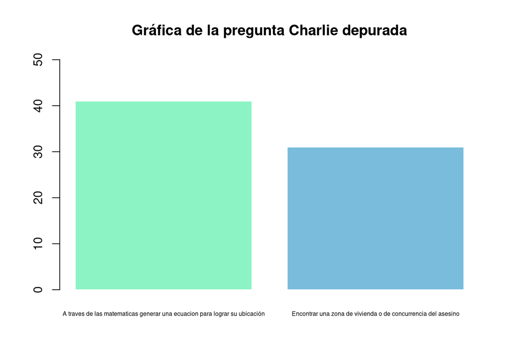

# Análisis de la técnica de Charlie

## Análisis

En una parte del capítulo Charlie establece una técnica para atrapar al asesino, se le preguntó a los estudiantes ¿cual era la técnica que Charlie uso para atrapar al asesino?.

A diferencia de la variable anterior, en esta variable podemos ver claramente que los agujeros negros es la respuesta que la mayoría eligió , y que la siguiente respuesta que es el punto de origen esta muy lejos de la cantidad de personas que respondieron la gran parte de los estudiantes.

En la reclasificación que yo puse, decidí eliminar los que no respondieron y solo dejar las respuestas: agujeros negros y punto de origen, las demas variables decidí renombrarlas bajo el nombre de otros ya que no hay un elemento común fuera de las otras dos respuestas.

## Tabla de la técnica de Charlie

```
##
##                   Agujeros negros Agujeros negros y punto de origen
##                                45                                 1
##               Distribucion normal                        El asesino
##                                 1                                 4
##                El punto de origen                Invertir el tiempo
##                                16                                 1
##                               N/N
##                                 2
```

## Grafica de la técnica de Charlie

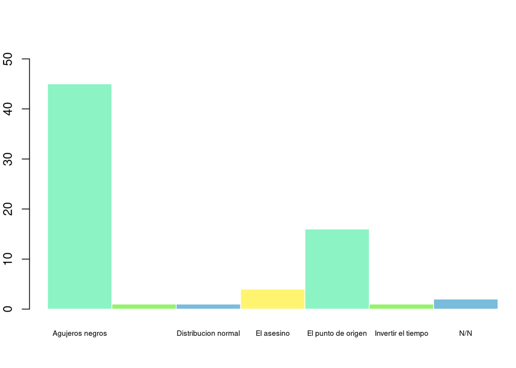

## Reclasificación de la técnica de Charlie

```
##                 Var1 Freq
## 1    Agujeros negros   46
## 5 El punto de origen   16
## 3              Otros    6
```

# Análisis de la razon por la cual no cogieron al asesino

## Análisis

En esta variable la mayoría de los estudiantes estan de acuerdo que la razón por la cual no se encontro al asesino en el primer intento fue porque solo usaron un foco, pero otra razón en el que los estudiantes pensaron que no pasó fue que el asesino se había mudado recientemente.

En la reclasificación de estas variables, separe algunas razones que incluían dos razones como: el asesino se habia mudado recientemente y no había tenido en cuenta el otro foco. Se sumo estas razon a el asesino se había mudad y se sumo a que no había tenido en cuenta el otro foco, de esa manera tener solamente tener razones atomicas y analizar como v cambiaban los resultados.

Se redujeron las variables a cinco y como un cambio significativo se nota que hay una reducción de la diferencia entre las dos mayores razones que eran el foco y la mudanza del asesino, lo que signifca que tal vez la razón por la cual no cogieron al asesino fue debido a estos dos factores y que la victima mintió.

## Tabla de la razon por la cual no cogieron al asesino

```
##
##                                      El asesino se habia mudado recientemente
##                                                                            21
## El asesino se habia mudado recientemente y no habia tenido encuenta otro foco
##                                                                             4
##                       Habia un dato erroneo por una victima y habia dos focos
##                                                                             5
##                                                        No analizo el problema
##                                                                             1
##                                                     Por utilizar solo un foco
##                                                                            31
##                                  Una victima mintio generando un dato erroneo
##                                                                            10
```

## Grafica de la razon por la cual no cogieron al asesino

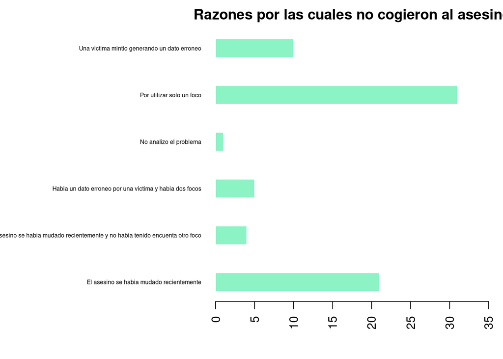

## Reclasificación de la razon por la cual no cogieron al asesino

```
##                                           Var1 Freq
## 5                    Por utilizar solo un foco   31
## 1     El asesino se habia mudado recientemente   25
## 6 Una victima mintio generando un dato erroneo   15
## 3              No tuvo en cuenta los dos focos    9
## 4                       No analizo el problema    1
```

# Análisis de la pregunta sobre cada cuanto un policía ganara la loteria

## Tabla

```
##    Min. 1st Qu.  Median    Mean 3rd Qu.    Max.
##       0   40000   40000  167792   40000 1000000
```

## Gráfica

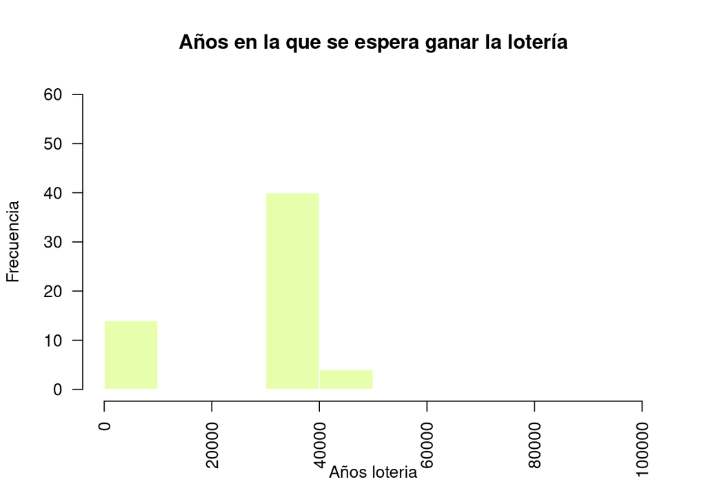

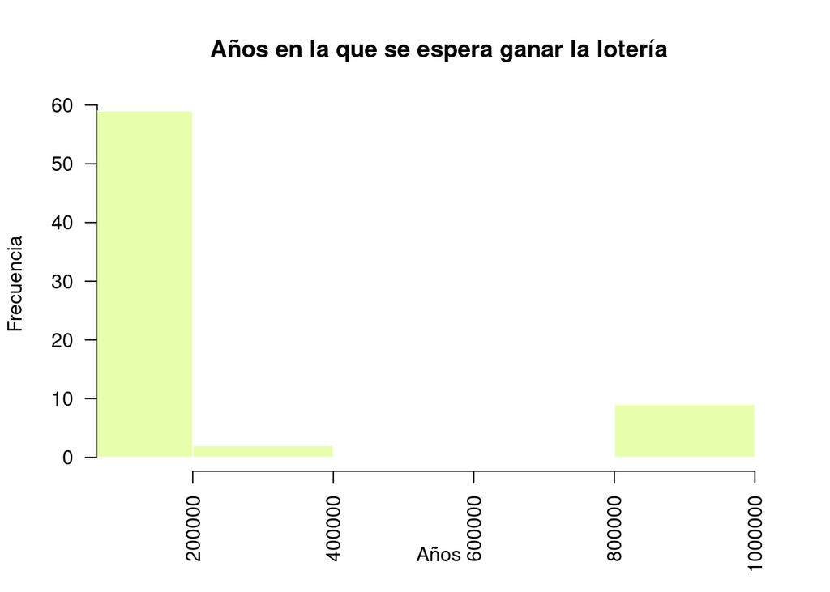

# Recomendaciones

Para la proxima actividad se recomienda comunicar mejor a los estudiantes lo que se debe realizar, para esto se podría poner un anuncio en la página del moodle del curso o decir la actividad reiteradamente en clase, debido a que el curso esta medido por la virtualidad es importante sobrecomunicar ya que uno debe asegurar que el mensaje llegue adecuadamente a todos los que estan en el curso, esto tambien debido a que como se evidenció en la excusas algunos todavía presentan problemas de conectividad o con sus computadores.

# Conclusiones

Debido a estos datos podemos evidenciar algunos de los retos que se tienen al dictar un curso virtualmente como la comunicación con los estudiantes o problemas técnicos con los dispositivos. A pesar de estas dificultades se evidencia que hay una buena participación en el curso mas de 100 personas contestaron la encuesta y un 60% realizaron la actividad, reconociendo la oprotunidad de mejora, el proximo curso se esperaría que más personas realicen la actividad.